# Analyze intertaxonomic distances.

Author

Thelma Panaïotis

```r
source("utils.R")
```

## Load data

```r
load("data/05c.inter_distances_ks.Rdata")
load("data/04b.null_ks.Rdata")
```

## Process data

Need to apply log transformation to number of distances and Kuiper statistic.

Let’s also identify taxonomic groups for which we have non random distances in order to plot them in colour.

```r
# Remove colonial Collodaria (segmentation artifact)
df_inter <- df_inter %>% filter(!str_detect(pair, "Collodaria_colonial"))
df_inter_dist <- df_inter_dist %>% filter(!str_detect(pair, "Collodaria_colonial"))

# Remove Rhizaria (poorly sorted)
df_inter <- df_inter %>% filter(!str_detect(pair, "Rhizaria"))
df_inter_dist <- df_inter_dist %>% filter(!str_detect(pair, "Rhizaria"))

# Log transform n dist and kuiper stat
df_inter <- df_inter %>%
  mutate(
    log_n_dist = log10(n_dist),
    log_kuiper_stat = log10(kuiper_stat)
  )

# Compute average for pairs A-B and B-A
df_inter <- df_inter %>%
  # separate pair into 2 taxonomic groups
  separate_wider_delim(pair, delim = "-", names = c("t1", "t2")) %>%
  # generate unsorted pair name (both A-B and B-A become A-B)
  mutate(
    pair_unsrt = ifelse(t1 < t2, paste(t1, t2, sep = "-"), paste(t2, t1, sep = "-")),
    .after = t2
  ) %>%
  select(-c(t1, t2)) %>%
  # group by unsorted pair and average all metrics
  group_by(pair_unsrt) %>%
  summarise_all(mean) %>%
  rename(pair = pair_unsrt)

# Keep only cases for which we have enough distances
df_inter <- df_inter %>% filter(n_dist > n_dist_min)

# Identify taxa above the threshold and that have enough distances
# First, get slope and intercept of the 0.95 qt regression
intercept <- null_ks_rq_coef %>% filter(tau == 0.95) %>% pull(intercept)
slope <- null_ks_rq_coef %>% filter(tau == 0.95) %>% pull(slope)
df_inter <- df_inter %>%
  mutate(
    above = log_kuiper_stat > slope * log_n_dist + intercept, # above the 0.95 qt reg
    enough = n_dist > n_dist_min, # are there enough distances
    sig = above & enough # significant if above and enough
    )

# Assign unique colour and shape to each taxon
df_inter_sig <- df_inter %>%
  filter(sig) %>%
   mutate(
    colour = chroma::hue_colors(sum(df_inter$sig)),
      #as.character(paletteer_d(`"khroma::discreterainbow"`, n = sum(df_inter$sig))),
    shape = rep(21:25, 20)[1:sum(df_inter$sig)]
  )#
```

## Results

### Kuiper statistic VS number of distances

All taxonomic groups.

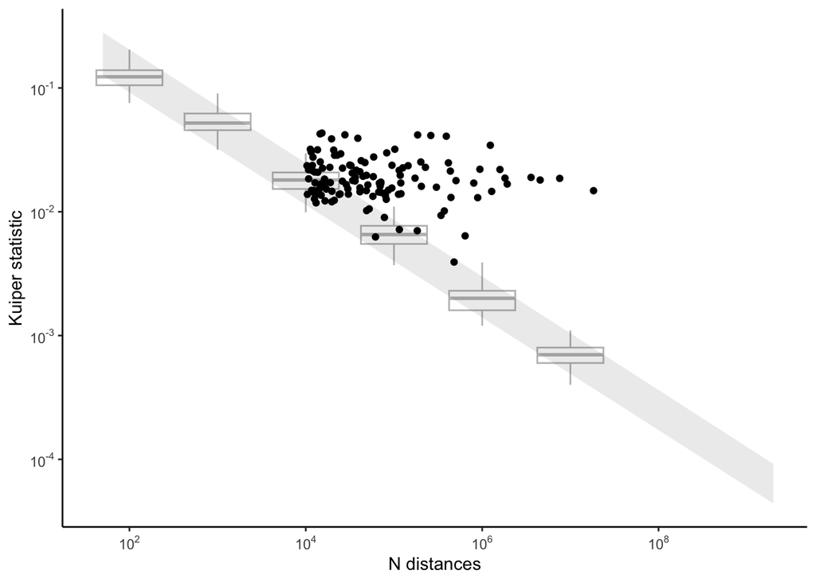

```r
ggplot() +
  geom_boxplot(data = null_ks_n_dist, aes(x = log_n_dist, y = log_kuiper_stat, group = log_n_dist), colour = "gray", outlier.shape = NA) +
  geom_polygon(data = null_ks_rib, aes(x = log_n_dist, y = y), alpha = 0.1) +
  geom_point(data = df_inter, aes(x = log_n_dist, y = log_kuiper_stat)) +
  labs(x = "N distances", y = "Kuiper statistic") +
  scale_fill_manual(values = df_inter_sig$colour) +
  scale_colour_manual(values = df_inter_sig$colour) +
  scale_shape_manual(values = df_inter_sig$shape) +
  scale_x_continuous(labels = label_math(expr = 10^.x, format = force), breaks = seq(2, 8, by = 2)) +
  scale_y_continuous(labels = label_math(expr = 10^.x, format = force)) +
  theme_classic()
```

Only those differing from random.

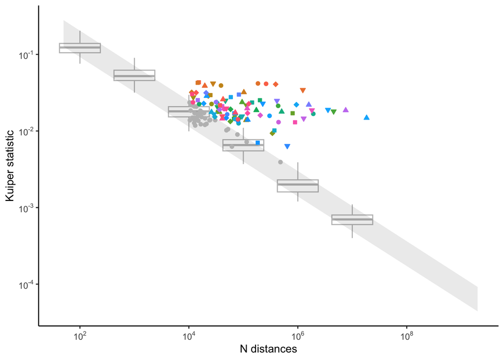

```r
ggplot() +
  geom_boxplot(data = null_ks_n_dist, aes(x = log_n_dist, y = log_kuiper_stat, group = log_n_dist), colour = "gray", outlier.shape = NA) +
  geom_polygon(data = null_ks_rib, aes(x = log_n_dist, y = y), alpha = 0.1) +
  geom_point(data = df_inter %>% filter(!sig), aes(x = log_n_dist, y = log_kuiper_stat), colour = "grey") +
  geom_point(data = df_inter_sig, aes(x = log_n_dist, y = log_kuiper_stat, colour = pair, fill = pair, shape = pair), show.legend = FALSE) +
  labs(x = "N distances", y = "Kuiper statistic") +
  scale_fill_manual(values = df_inter_sig$colour) +
  scale_colour_manual(values = df_inter_sig$colour) +
  scale_shape_manual(values = df_inter_sig$shape) +
  scale_x_continuous(labels = label_math(expr = 10^.x, format = force), breaks = seq(2, 8, by = 2)) +
  scale_y_continuous(labels = label_math(expr = 10^.x, format = force)) +
  theme_classic()
```

### Distribution of distances

Start by plotting distribution of distances for a subsample of significant pairs.

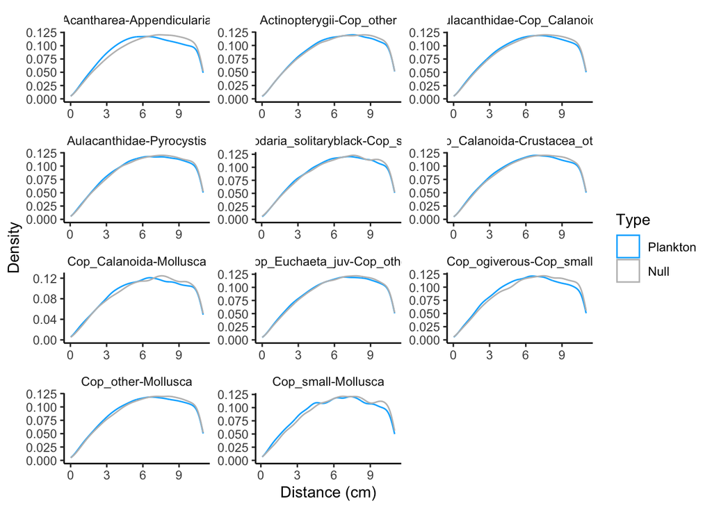

```r
# Reformat the distance dataframe
df_inter_dist <- df_inter_dist %>%
  pivot_longer(plank_qt:rand_qt, names_to = "type", values_to = "dist") %>%
  mutate(
    type = ifelse(type == "plank_qt", "Plankton", "Null"), # nicer names
    type = factor(type, levels = c("Plankton", "Null")) # convert to factor
    ) %>%
  # keep only significant groups
  filter(pair %in% df_inter_sig$pair)

pairs_to_plot <- df_inter_sig %>% slice_sample(n = 12)

ggplot(df_inter_dist %>% filter(pair %in% pairs_to_plot$pair)) +
  geom_density(aes(x = dist, colour = type)) +
  scale_colour_manual(values = c("#00B2FF", "grey"), labels = c("Plankton", "Null")) +
  labs(x = "Distance (cm)", y = "Density", colour = "Type") +
  theme_classic() +
  theme(strip.background = element_rect(colour = "white")) +
  facet_wrap(~pair, scales = "free", ncol = 3)
```

Let’s plot ECDF.

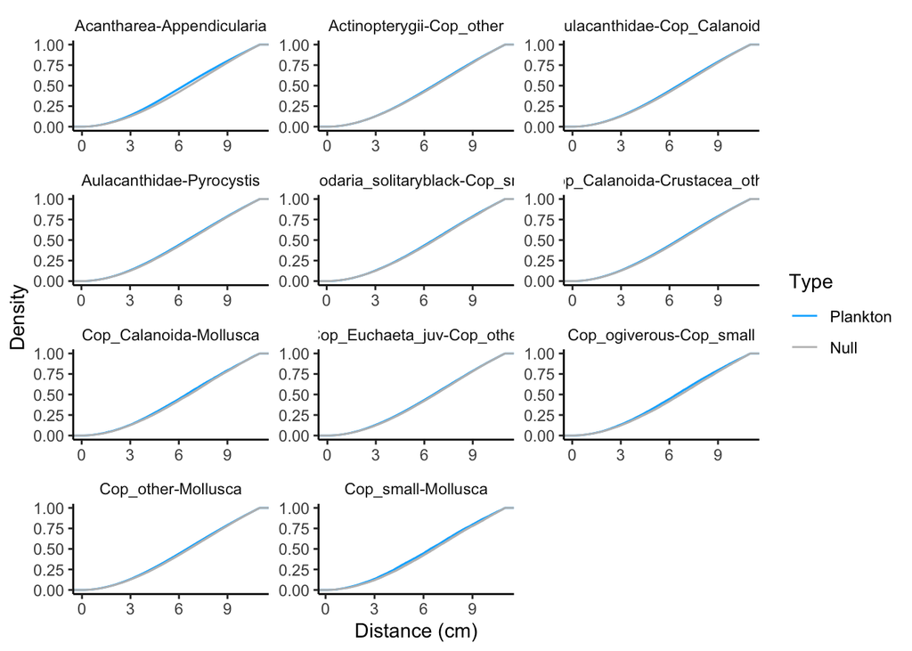

```r
ggplot(df_inter_dist %>% filter(pair %in% pairs_to_plot$pair)) +
  stat_ecdf(aes(x = dist, colour = type)) +
  scale_colour_manual(values = c("#00B2FF", "grey"), labels = c("Plankton", "Null")) +
  labs(x = "Distance (cm)", y = "Density", colour = "Type") +
  theme_classic() +
  theme(strip.background = element_rect(colour = "white")) +
  facet_wrap(~pair, scales = "free", ncol = 3)
```

To automatically detect the sense of variation, we can compute the difference between plankton ECDF and null ECDF.

First, we need to compute ECDFs.

```r
# X axis on which to compute ECDFs
x_axis_seq <- seq(0, dist_thr, length.out = 1000)

# Reshape df to have one row per pair
df_inter_dist_wide <- df_inter_dist %>%
  pivot_wider(names_from = type, values_from = dist, values_fn = list) %>%
  filter(pair %in% df_inter_sig$pair)

# Loop over taxa
ecdfs_inter <- lapply(1:nrow(df_inter_dist_wide), function(i) {
  # Get row
  r <- df_inter_dist_wide %>% slice(i)

  # Compute ecdf
  # Needs a nested call: ecdf(x) returns a function, x being the values of interest
  # Call this function with argument x2 to get values along x2 (here, plankton distances so that we have a common x axis)
  plank_ecdf <- ecdf(unlist(r$Plankton))(x_axis_seq)
  null_ecdf <- ecdf(unlist(r$Null))(x_axis_seq)

  # Return difference
  res <- tibble(
    x_axis_seq = x_axis_seq,
    plank_ecdf = plank_ecdf,
    null_ecdf = null_ecdf,
    diff = plank_ecdf - null_ecdf
    ) %>%
    mutate(pair = r$pair) %>% # add pair
    select(pair, everything())
  return(res)
}) %>%
  bind_rows()
```

Now let’s plot the difference between plankton ECDF and null ECDF.

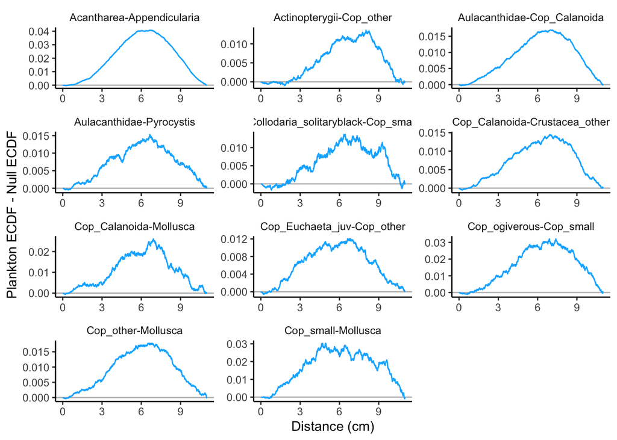

```r
ggplot(ecdfs_inter %>% filter(pair %in% pairs_to_plot$pair)) +
  geom_hline(yintercept = 0, colour = "gray") +
  geom_path(aes(x = x_axis_seq, y = diff), colour = "#00B2FF") +
  labs(x = "Distance (cm)", y = "Plankton ECDF - Null ECDF") +
  theme_classic() +
  theme(strip.background = element_rect(colour = "white")) +
  facet_wrap(~pair, scales = "free", ncol = 3)
```

Now let’s automatically detect which ECDF is above for all pairs.

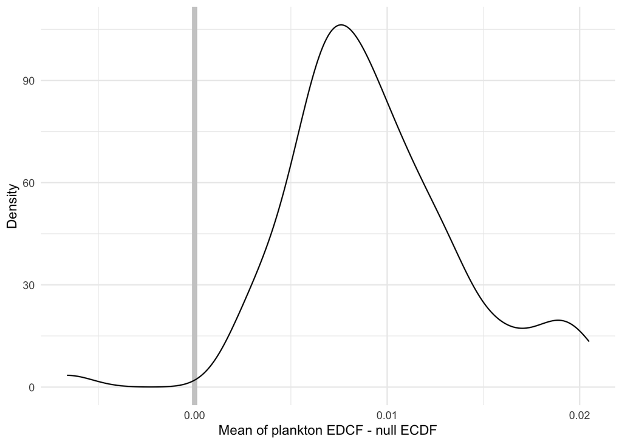

```r
ecdfs_inter_summ <- ecdfs_inter %>%
  group_by(pair) %>%
  summarise(mean_diff = mean(diff)) %>%
  mutate(dir = ifelse(mean_diff > 0, "closer", "further"))
ggplot(ecdfs_inter_summ) +
  geom_vline(xintercept = 0, colour = "grey80", linewidth = 2) +
  geom_density(aes(x = mean_diff)) +
  labs(x = "Mean of plankton EDCF - null ECDF", y = "Density")
```

For nearly all pairs groups, plankton ECDF is above null ECDF, indicating more short distances, i.e. planktonic organisms are closer than expected. Let’s check pairs for which distances are longer than expected.

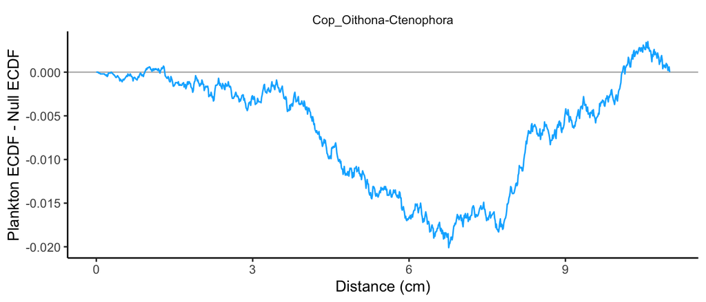

```r
# Detect pairs for which ECDFs differences is negative
pairs_further <- ecdfs_inter_summ %>% filter(mean_diff < 0)

# Plot ECDF differences
ggplot(ecdfs_inter %>% filter(pair %in% pairs_further$pair)) +
  geom_hline(yintercept = 0, colour = "gray") +
  geom_path(aes(x = x_axis_seq, y = diff), colour = "#00B2FF") +
  labs(x = "Distance (cm)", y = "Plankton ECDF - Null ECDF") +
  theme_classic() +
  theme(strip.background = element_rect(colour = "white")) +
  facet_wrap(~pair, scales = "free", ncol = 3)
```

### Plot quantile difference VS distance percentile

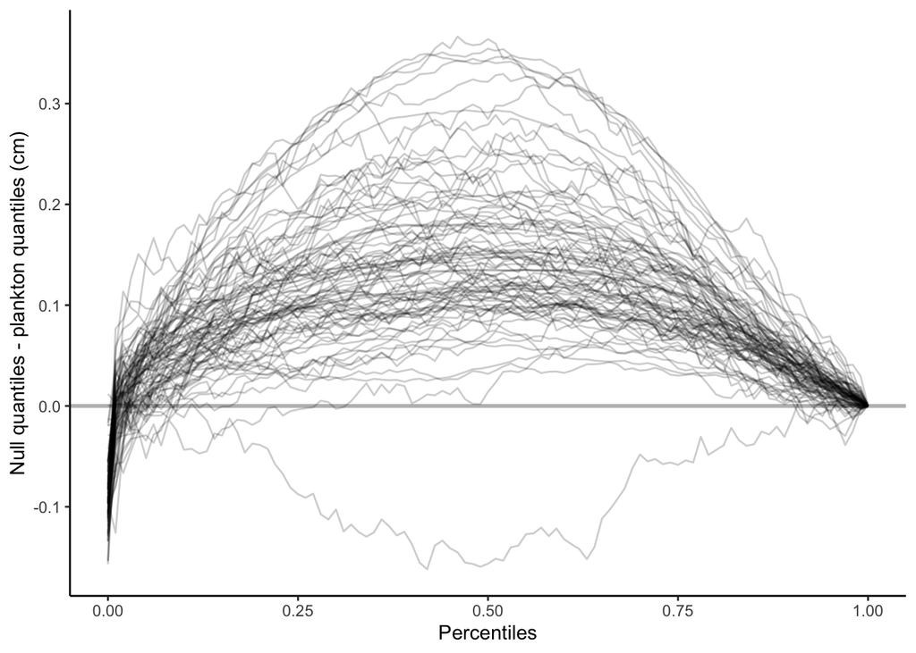

```r
# Plot differences in quantiles
df_inter_qt <- df_inter_dist %>%
  mutate(type = str_to_lower(type)) %>%
  group_by(pair, type) %>% # separately for plankton and null
  reframe(dist = quantile(dist, probs = seq(0, 1, by = 0.01))) %>% # compute percentiles
  pivot_wider(names_from = type, values_from = dist, values_fn = list) %>% # plankton and null quantiles in two columns
  unnest(c(plankton, null)) %>%
  mutate(
    diff = null - plankton, # compute difference between null and plankton quantiles
    x_axis = rep(seq(0, 1, by = 0.01), length.out = n()) # add percentiles for X axis sequence,
  )

ggplot(df_inter_qt) +
  geom_hline(yintercept = 0, colour = "grey", linewidth = 1) +
  geom_path(aes(x = x_axis, y = diff, group = pair), alpha = 0.2) +
  labs(x = "Percentiles", y = "Null quantiles - plankton quantiles (cm)") +
  theme_classic()
```

Let’s now compute the interaction strength and confidence for each pair.

### Interaction strength & confidence

Interaction strength corresponds to the Kuiper statistic while confidence is computed as the Z-score between Kuiper statistic and the distribution of null Kuiper statistics.

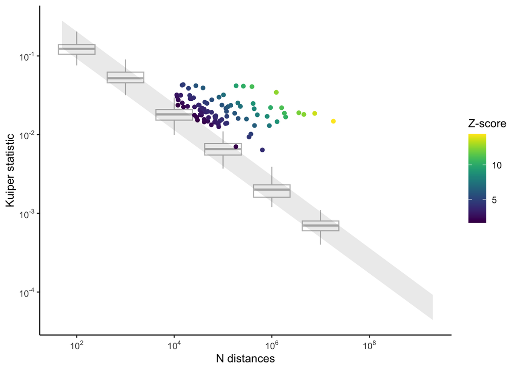

```r
# Compute Z-scores
df_inter_scores <- df_inter %>%
  mutate(
    # compute estimated mean, 5th and 95th percentiles kuiper-stat from slope and intercept
    ymin =
      null_ks_rq_coef %>% filter(tau == 0.05) %>% pull(slope) * log_n_dist +
      null_ks_rq_coef %>% filter(tau == 0.05) %>% pull(intercept),
    ymean =
      null_ks_rq_coef %>% filter(tau == "mean") %>% pull(slope) * log_n_dist +
      null_ks_rq_coef %>% filter(tau == "mean") %>% pull(intercept),
    ymax =
      null_ks_rq_coef %>% filter(tau == 0.95) %>% pull(slope) * log_n_dist +
      null_ks_rq_coef %>% filter(tau == 0.95) %>% pull(intercept),
    # compute sigma
    sigma = (ymax - ymin) / (2 * 1.645),
    # compute z-score
    z_score = (log_kuiper_stat - ymean)/sigma
  ) %>%  # add intercation direction
  left_join(ecdfs_inter_summ, by = join_by(pair))

# Plot Z-score
ggplot() +
  geom_boxplot(data = null_ks_n_dist, aes(x = log_n_dist, y = log_kuiper_stat, group = log_n_dist), colour = "gray", outlier.shape = NA) +
  geom_polygon(data = null_ks_rib, aes(x = log_n_dist, y = y), alpha = 0.1) +
  geom_point(data = df_inter_scores %>% filter(sig), aes(x = log_n_dist, y = log_kuiper_stat, colour = z_score)) +
  labs(x = "N distances", y = "Kuiper statistic", colour = "Z-score") +
  scale_colour_viridis_c() +
  scale_x_continuous(labels = label_math(expr = 10^.x, format = force), breaks = seq(2, 8, by = 2)) +
  scale_y_continuous(labels = label_math(expr = 10^.x, format = force)) +
  theme_classic()
```

Plot Z-score VS Kuiper statistic for significant taxa.

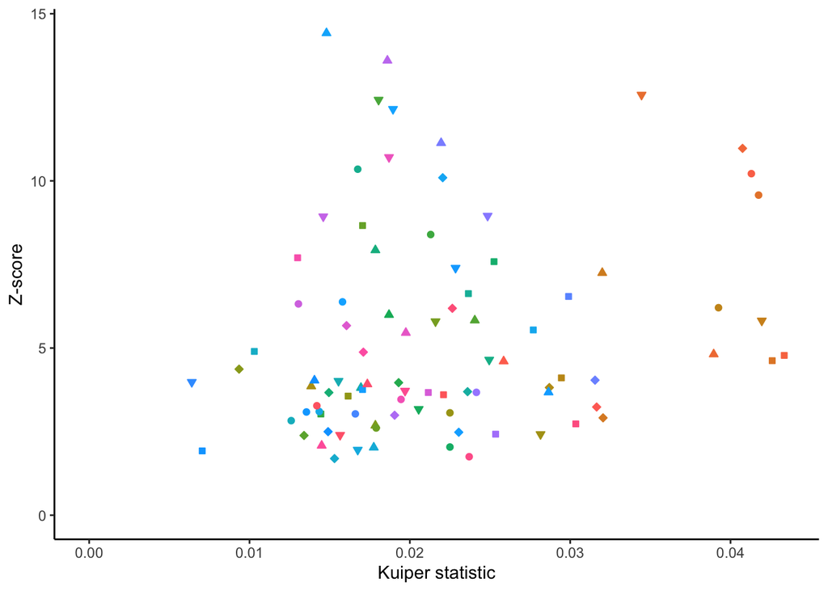

```r
df_inter_scores %>%
  filter(sig) %>%
  ggplot() +
  geom_point(aes(x = kuiper_stat, y = z_score, colour = pair, fill = pair, shape = pair), show.legend = FALSE) +
  scale_colour_manual(values = df_inter_sig$colour) +
  scale_fill_manual(values = df_inter_sig$colour) +
  scale_shape_manual(values = df_inter_sig$shape) +
  labs(x = "Kuiper statistic", y = "Z-score") +
  expand_limits(x = 0, y = 0) +
  theme_classic()
```

## Save

Save Z-score and Kuiper stat.

Save quantiles, Z-score and Kuiper stat.

```r
save(df_inter_qt, file = "data/06c.df_inter_qt.Rdata")
save(df_inter_scores, file = "data/06c.df_inter_scores.Rdata")
```